# Hawaiian SFPW movement analysis

Amy Van Cise

April 18, 2017

## Introduction

This workshop is an introduction to the use of the crawl package to predict individual movement paths from the posterior distributin of a correlated random walk model. Using the model fits, we can calculate utilization distributions for comparison with environmental variables.

## Data plot

Using leaflet, an interactive plot of the data for two individuals.

[figure not shown]

### Crawl model fit

For each individual, fit a correlated random walk model to the data and estimate parameters a and P.

```
##
## ------------------------------------------------------------------
##         term          estimate   std.error   conf.low   conf.high
## -------------------- ---------- ----------- ---------- -----------
##     ln tau lc943       5.131       0.187      4.765       5.497
##
##     ln tau lc942       6.194       0.126      5.948       6.44
##
##     ln tau lc941       7.141       0.107      6.931       7.352
##
##     ln tau lc940       8.098       0.102      7.898       8.298
##
##     ln tau lc94A       8.354       0.203      7.955       8.752
##
##     ln tau lc94B       7.836       0.166      7.511       8.162
##
## ln sigma (Intercept)   4.451       0.068      4.317       4.584
##
## ln beta (Intercept)    -9.156      0.175       -9.5      -8.812
##
##        logLik          -4352        NA          NA         NA
##
##         AIC             8721        NA          NA         NA
## ------------------------------------------------------------------
##
## Table: crwMLE fit parameters
##
##
## ------------------------------------------------------------------
##         term          estimate   std.error   conf.low   conf.high
## -------------------- ---------- ----------- ---------- -----------
##     ln tau lc943        5.35       0.196      4.965       5.735
##
##     ln tau lc942       6.208       0.153      5.907       6.509
##
##     ln tau lc941       6.592       0.191      6.217       6.968
##
##     ln tau lc940       6.864       0.399      6.081       7.646
##
##     ln tau lc94A        7.29       0.319      6.665       7.915
##
##     ln tau lc94B       7.855       0.22       7.423       8.286
##
## ln sigma (Intercept)    4.17       0.046       4.08       4.261
##
## ln beta (Intercept)    -6.95       0.33       -7.597     -6.303
##
##        logLik          -3513        NA          NA         NA
##
##         AIC             7043        NA          NA         NA
## ------------------------------------------------------------------
##
## Table: crwMLE fit parameters
```

### Predicted paths

Using the fit parameters, predict the most likely paths for two animals. The below graphs show the estimated x and y track for each individual, and then a final map pulling all the data together.

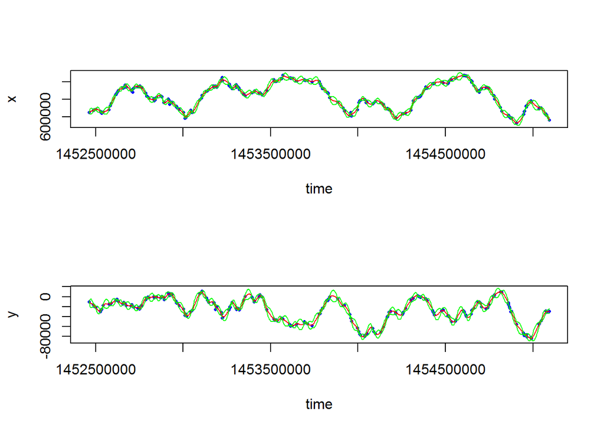

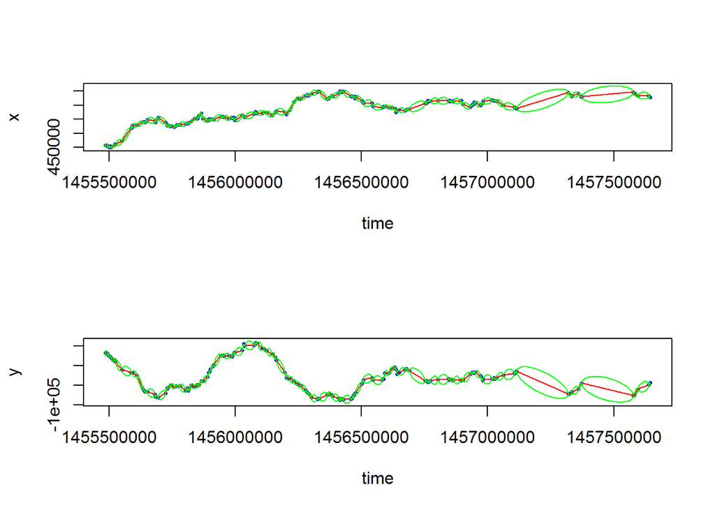

[figure not shown]

## Simulate error in track prediction

[figure not shown]